# Project 2

Mary de Boer

2024-09-24

## Part 1: Functions

### 1A: Exponential Functions

I developed the exponential function below, which will give an output of NULL if k is not an integer, if k is less than 1, or if k is really large (greater than 100).

```r
Exp <- function(x, k) {
  if (k <1 || k >100 || k %% 1 != 0) {
    cat("value of k must be an integere >=1 and <=100")
    return(NULL)
    }
    answer <- 1
    for(i in 1:k){
      answer <- answer + (x^i)/factorial(i)
    }
    return(answer)
  }


Exp(2,3)
```

```
## [1] 6.333333
```

```r
Exp(2, 1.5)
```

```
## value of k must be an integere >=1 and <=100
```

```r
Exp(2, 0)
```

```
## value of k must be an integere >=1 and <=100
```

```r
Exp(2, 101)
```

```
## value of k must be an integere >=1 and <=100
```

```r
Exp(2, 90)
```

```
## [1] 7.389056
```

```r
Exp(70,70)
```

```
## [1] 1.337536e+30
```

### 1B: Sample mean and Std deviation functions

I developed the following functions and am showing some of their sample output below.

```r
sample_mean <- function (x) {
  answer <-sum(x)/length(x)
  return(answer)
}

x<-1:100
sample_mean(x)
```

```
## [1] 50.5
```

```r
sample_sd <- function (x) {
  xbar <- sum(x)/length(x)
  diff <- sum((x - xbar)^2)
  inside <- diff/(length(x)-1)
  stdev <- sqrt(inside)
  return(stdev)
  }

sample_sd(x)
```

```
## [1] 29.01149
```

### Part 1C: Confidence intervals

I developed a calculate_CI function that has the default of 95% percent, but takes as its inputs x (a vector of length N), and conf (the level of confidence that is desired if not 95%). It calculated the 95% CI of x, and returns a two-item named vector, with the first value named “lower_bound” and the second value named “upper_bound.”

I am including two different sample confidence intervals, using two different confidence levels (the default 95% and a more stringent 99%).

```r
calculate_CI <- function (x, conf = 0.95) {
  alpha <- 1 - conf
  degrees_freedom <- length(x) - 1
  t_score <- qt(p = alpha / 2, df = degrees_freedom, lower.tail = FALSE)
  se <- sd(x)/sqrt(length(x))
  lower_bound <- mean(x)-t_score*se
  upper_bound <- mean(x)+t_score*se
  CI <- c(lower_bound = lower_bound, upper_bound=upper_bound)
  return(CI)
}

calculate_CI(x)
```

```
## lower_bound upper_bound
##    44.74349    56.25651
```

```r
calculate_CI(x, 0.99)
```

```
## lower_bound upper_bound
##    42.88041    58.11959
```

## Part 2: Data Wrangling

I used the Tidy Tuesday datasets for rainfall and temperature and completed the following tasks:

1. I dropped any rows in the rainfall dataset with NAs (using (complete.cases(.)).
2. Created a new date column formatted “YYYY-MM-DD” that is recognizable as a date by R (using lubridate’s make_date).
3. Converted the city names to all upper case letters (using tidyverse’s toupper)
4. Conducted an inner join between the rainfall and temperature datasets, matching on city name and date, to produce a dataset with 83,964 rows and 13 columns.

```r
rainfall <- readRDS(here("data", "tuesdata_rainfall.RDS"))
temperature <- readRDS(here("data", "tuesdata_temperature.RDS"))

# Remove Rainfall NAs
rainfall <- rainfall %>% filter(complete.cases(.))

# Combine columns and make date column of YYYY-MM-DD
rainfall <- rainfall %>% mutate(date = make_date(year, month, day)) %>%
  select(- month, - day)

# Recognizable as date by R
class(rainfall$date)
```

```
## [1] "Date"
```

```r
# Change case of city name's
rainfall <- rainfall %>% mutate(city_name =toupper(city_name))

#Check that all names are uppercase
head(rainfall$city_name)
```

```
## [1] "PERTH" "PERTH" "PERTH" "PERTH" "PERTH" "PERTH"
```

```r
# Do an inner join and only keep data matched by city name and date
joined_data <- inner_join(rainfall, temperature, by = c("city_name", "date"))
#Check final dimensions
dim(joined_data)
```

```
## [1] 83964    13
```

## Part 3: Data Visualization

### Part 3A: Plotting temperature data over time

I graphed the max and min temperatures from 2014 for each city in the data set, with each trendline shown in a different color. The graph is faceted by city_name to show all cities in one figure.

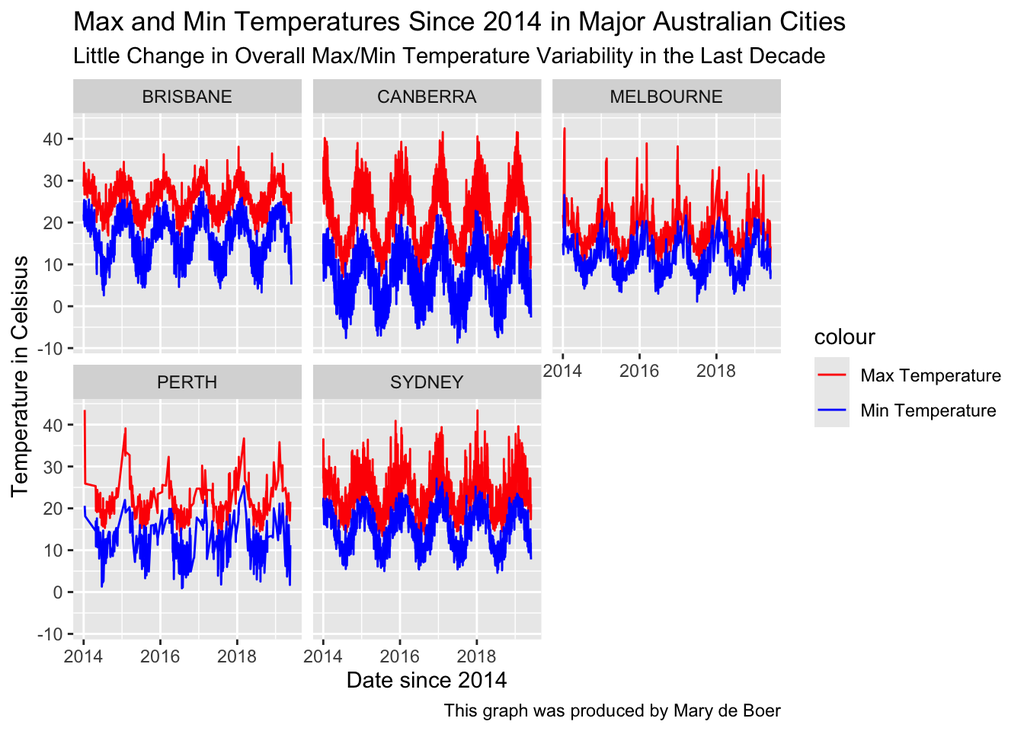

```r
#Filter for years after 2014
df <- joined_data %>% filter(year >= 2014)

# Produce summary temp statistics
df <- df %>%
  group_by(date, city_name) %>%
  summarize(
    max_temperature = max(temperature),
    min_temperature = min(temperature),
    .groups = "drop"
  )

#plot
ggplot(df, aes(x=date)) +
 geom_line(aes(y =max_temperature, color = "Max Temperature")) +
  geom_line(aes(y =min_temperature, color = "Min Temperature")) +
  facet_wrap(~city_name)+
  labs(title = "Max and Min Temperatures Since 2014 in Major Australian Cities",
       subtitle = "Little Change in Overall Max/Min Temperature Variability in the Last Decade",
       caption = "This graph was produced by Mary de Boer",
      x = "Date since 2014",
      y = "Temperature in Celsisus") +
  scale_color_manual(values = c("Max Temperature" = "red", "Min Temperature" = "blue"))
```

1. I chose to design my function to take as its arguments any version of the city name supplied (upper, lower, in quotes, without) and year as its two arguments. I rendered the city_name as an all-caps character and also kept a title case version to use for the final graphics. Then, I included code to check whether the year and city name exist in the data set. I used the double ampersand to make sure that the first item was evaluated first. the in operator (%in%) which checks if elements in one vector exist within another one, and the exclamation point to negate the expression. If the city_name and/or the year is not in the data frame, it will give an error message. For the actual plot, I used the code mostly as supplied, incorporating colors but also I learned that I had to add the “!” before the name of the input in order for R to read it as an input rather than as the corresponding column title from the joined data frame. I used the paste function with the space separator to produce the titles of the graphs. I am including two different sample outputs below.

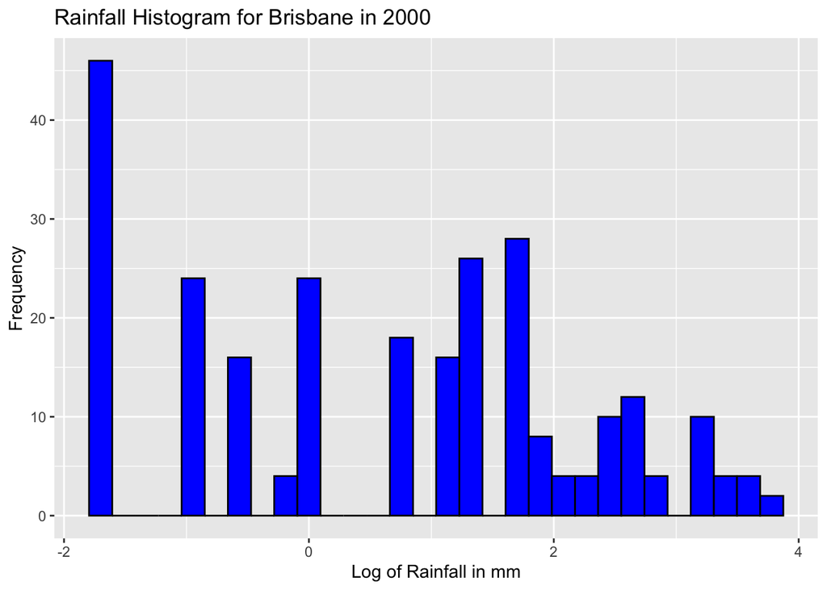

```r
city_hist <- function (city_name, year) {
  # Convert city_name argument to string if passed as a symbol
  city_name <- as.character(toupper((substitute(city_name))))

  #Make a version for the ggplot
  city_name_formatted <- tools::toTitleCase(tolower(city_name))

  # Check if the combination of city and year exists in the data
  if (!(city_name %in% unique(joined_data$city_name) && year %in% unique(joined_data$year))) {
    stop("This combination of city and year does not exist in the dataset.")
  }


  joined_data %>%
    filter(city_name == !!city_name, year == !!year) %>%
    ggplot(aes(log(rainfall))) +
    geom_histogram(fill = "blue", color = "black") +
    labs(title = paste("Rainfall Histogram for", city_name_formatted, "in", year),
         x = "Log of Rainfall in mm",
         y = "Frequency")
}

city_hist(Brisbane, 2000)
```

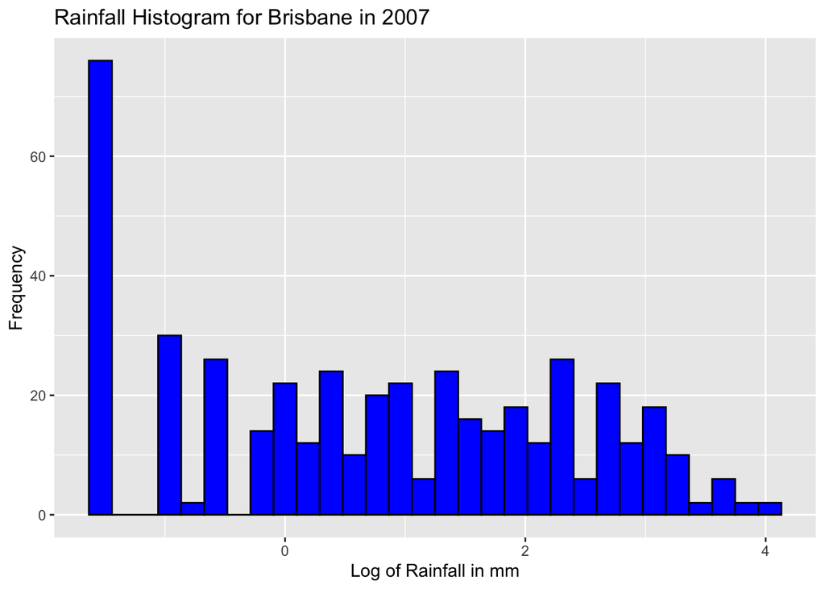

```r
city_hist(BRISBANE, 2007)
```

1. First, I filtered for years from 2014 onward.
2. Then, I grouped the data by city and by year, and used summarize, applying the sample_mean() and sample_sd() functions to the grouped data on rainfall.
3. I struggled with how to use the confidence interval output, ultimately producing it as a list and then turning it into two new columns subsequently using sapply and mutate.
4. I named the summarized dataset rain_df.

```r
rain_df <- joined_data %>%
  filter(year >= 2014) %>%
  group_by(city_name, year) %>%
  summarise(mean_rainfall = sample_mean(rainfall), sd = sample_sd(rainfall),
            CI = list(calculate_CI(rainfall))) %>%
  mutate(
    CI_LB = sapply(CI, function(x) x[["lower_bound"]]),  # Extract lower bounds
    CI_UB = sapply(CI, function(x) x[["upper_bound"]])   # Extract upper bounds
  ) %>%
  select(-CI)
head(rain_df)
```

```
## # A tibble: 6 × 6
## # Groups:   city_name [1]
##   city_name  year mean_rainfall    sd CI_LB CI_UB
##   <chr>     <dbl>         <dbl> <dbl> <dbl> <dbl>
## 1 BRISBANE   2014          3.84 12.3   2.99  4.69
## 2 BRISBANE   2015          6.17 22.7   4.53  7.82
## 3 BRISBANE   2016          2.09  8.61  1.47  2.72
## 4 BRISBANE   2017          2.72 10.2   1.97  3.47
## 5 BRISBANE   2018          2.47  9.63  1.75  3.19
## 6 BRISBANE   2019          2.10  6.35  1.38  2.82
```

### Part 4B: Tasks

For this task, I produced the following graph, reading the instructions for how to use geom_error bar. It depicts mean rainfall and the upper and lower 95% confidence bounds for the selected cities since 2014.

[figure not shown]

```r
ggplot(rain_df, aes(x=year)) +
  geom_line(aes(y =mean_rainfall)) +
  geom_errorbar(aes(ymin = CI_LB, ymax = CI_UB), width = .2) +
  facet_wrap(~city_name)+
  labs(title = "Mean Rainfall in Major Australian Cities Since 2014",
       subtitle = "Declining average rainfall is seen in all cities except Canberra",
       caption = "This graph was (proudly) produced by Mary de Boer",
       x = "Date (years)",
       y = "Rainfall (mm)")
```